# Proteomic comparison of regulatory and conventional mouse T-cells (Fanny Duguet)

Marie Locard-Paulet

2016-12-06

# The data

Here are the different steps of the analysis:

1. I remove all the contaminants by getting rid of the `Majority.protein.IDs` containing `REV\_` or `CON\_`. I also remove the proteins identified with less than 2 unique peptides.
2. The quantification is performed with the LFQ normalised intensity values (column names starting with `LFQ.intensity`).
3. 0 are replaced by `NAs`.
4. Proteins with `NAs` in all conditions are removed.
5. I log2-transform the LFQ intensities.
6. All the NA values are replaced by the noise (1% quantile of all the LFQ values of the file).
7. I keep the proteins where there are at least 3 values from independent experiments in the Tconv or the Treg.
8. The means per biological replicate are calculated for each cell population.
9. A paired 2-sided t-test is performed to identify proteins differencially regulated in the 2 cell populations.
10. Proteins with a p-value under or equal to 0.05 and with a fold change (log2(Treg/Tconv)) above 1 or under -1 (i.e. 2-fold regulation) are selected, their p-values are adjusted (BH) and the proteins with an adjusted-pvalue under or equal to 0.05 are considered significantly regulated.

The biological replicates are independent experiments. These are labelled:

A file `FilesList.txt` in the folder `MappingTables/` allows the mapping of all raw files, gradient times and replicate names for the analysis.

| Raw.file.name | Instrument | Gradient.length | Sample.Type | Biological.replicate | MS.technical.replicate | Column.name.in.the.MaxQuant.output.files..initial.name. | Column.name.in.Supplementary.Table.1..Duguet.et.al. | Biological.group | Biological.sample |
| --- | --- | --- | --- | --- | --- | --- | --- | --- | --- |
| OEAGP120906_03 | LTQ-Orbitrap-Velos | 480min | Tconv | 1 | inj1 | Tconv M5_inj1 | Tconv_1_inj1 | Tconv | M5 |
| OEAGP120906_19 | LTQ-Orbitrap-Velos | 480min | Tconv | 1 | inj2 | Tconv M5_inj2 | Tconv_1_inj2 | Tconv | M5 |
| OEAGP120906_01 | LTQ-Orbitrap-Velos | 480min | Treg | 1 | inj1 | Treg M5_inj1 | Treg_1_inj1 | Treg | M5 |
| OEAGP120906_17 | LTQ-Orbitrap-Velos | 480min | Treg | 1 | inj2 | Treg M5_inj2 | Treg_1_inj2 | Treg | M5 |
| OEMMA121024_18 | LTQ-Orbitrap-Velos | 480min | Tconv | 2 | inj1 | Tconv M6_inj1 | Tconv_2_inj1 | Tconv | M6 |
| OEMMA121024_20 | LTQ-Orbitrap-Velos | 480min | Tconv | 2 | inj2 | Tconv M6_inj2 | Tconv_2_inj2 | Tconv | M6 |
| OEMMA121024_22 | LTQ-Orbitrap-Velos | 480min | Tconv | 2 | inj3 | Tconv M6_inj3 | Tconv_2_inj3 | Tconv | M6 |
| OEMMA121024_28 | LTQ-Orbitrap-Velos | 480min | Treg | 2 | inj1 | Treg M6_inj1 | Treg_2_inj1 | Treg | M6 |
| OEMMA121024_30 | LTQ-Orbitrap-Velos | 480min | Treg | 2 | inj2 | Treg M6_inj2 | Treg_2_inj2 | Treg | M6 |
| OEMMA121024_33 | LTQ-Orbitrap-Velos | 480min | Treg | 2 | inj3 | Treg M6_inj3 | Treg_2_inj3 | Treg | M6 |
| QEAGP140802_06 | Q-ExactivePlus | 300min | Tconv | 3 | inj1 | Tconv M11_R1_inj1 | Tconv_3_inj1 | Tconv | M11_R1 |
| QEAGP140802_10 | Q-ExactivePlus | 300min | Tconv | 3 | inj2 | Tconv M11_R1_inj2 | Tconv_3_inj2 | Tconv | M11_R1 |
| QEAGP140802_14 | Q-ExactivePlus | 300min | Tconv | 3 | inj3 | Tconv M11_R1_inj3 | Tconv_3_inj3 | Tconv | M11_R1 |
| QEAGP140802_08 | Q-ExactivePlus | 300min | Treg | 3 | inj1 | Treg M11_R1_inj1 | Treg_3_inj1 | Treg | M11_R1 |
| QEAGP140802_12 | Q-ExactivePlus | 300min | Treg | 3 | inj2 | Treg M11_R1_inj2 | Treg_3_inj2 | Treg | M11_R1 |
| QEAGP140802_16 | Q-ExactivePlus | 300min | Treg | 3 | inj3 | Treg M11_R1_inj3 | Treg_3_inj3 | Treg | M11_R1 |
| QEAGP140806_03 | Q-ExactivePlus | 300min | Tconv | 4 | inj1 | Tconv M11_R2_inj1 | Tconv_4_inj1 | Tconv | M11_R2 |
| QEAGP140806_12 | Q-ExactivePlus | 300min | Tconv | 4 | inj2 | Tconv M11_R2_inj2 | Tconv_4_inj2 | Tconv | M11_R2 |
| QEAGP140806_20 | Q-ExactivePlus | 300min | Tconv | 4 | inj3 | Tconv M11_R2_inj3 | Tconv_4_inj3 | Tconv | M11_R2 |
| QEAGP140806_05 | Q-ExactivePlus | 300min | Treg | 4 | inj1 | Treg M11_R2_inj1 | Treg_4_inj1 | Treg | M11_R2 |
| QEAGP140806_14 | Q-ExactivePlus | 300min | Treg | 4 | inj2 | Treg M11_R2_inj2 | Treg_4_inj2 | Treg | M11_R2 |
| QEAGP141203_10 | Q-ExactivePlus | 300min | Tconv | 5 | inj1 | Tconv M12_1 | Tconv_5_inj1 | Tconv | M12_1 |
| QEAGP141203_12 | Q-ExactivePlus | 300min | Treg | 5 | inj1 | Treg M12_1 | Treg_5_inj1 | Treg | M12_1 |
| QEAGP141203_14 | Q-ExactivePlus | 300min | Tconv | 6 | inj1 | Tconv M12_2 | Tconv_6_inj1 | Tconv | M12_2 |
| QEAGP141203_16 | Q-ExactivePlus | 300min | Treg | 6 | inj1 | Treg M12_2 | Treg_6_inj1 | Treg | M12_2 |
| QEAGP141203_18 | Q-ExactivePlus | 300min | Tconv | 7 | inj1 | Tconv M12_3 | Tconv_7_inj1 | Tconv | M12_3 |
| QEAGP141203_20 | Q-ExactivePlus | 300min | Treg | 7 | inj1 | Treg M12_3 | Treg_7_inj1 | Treg | M12_3 |

From the MaxQuant export table, there are 4562 unique “Majority.protein.IDs”. After removing the contaminants, 4345 remain, and 3998 remain when we keep the protein with a minimum of 2 unique peptide. After removing the rows with only NAs, there are 3997 unique “Majority.protein.IDs” remaining.

Pairwise plots of the raw values per biological experiment with technical replicates:

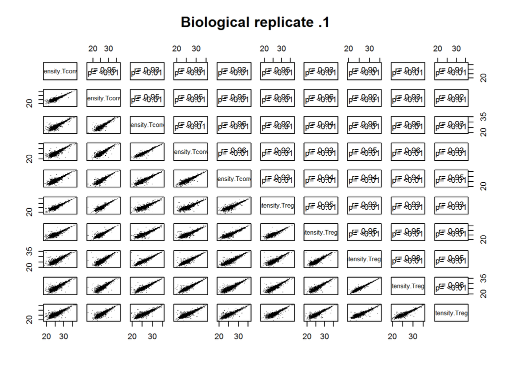

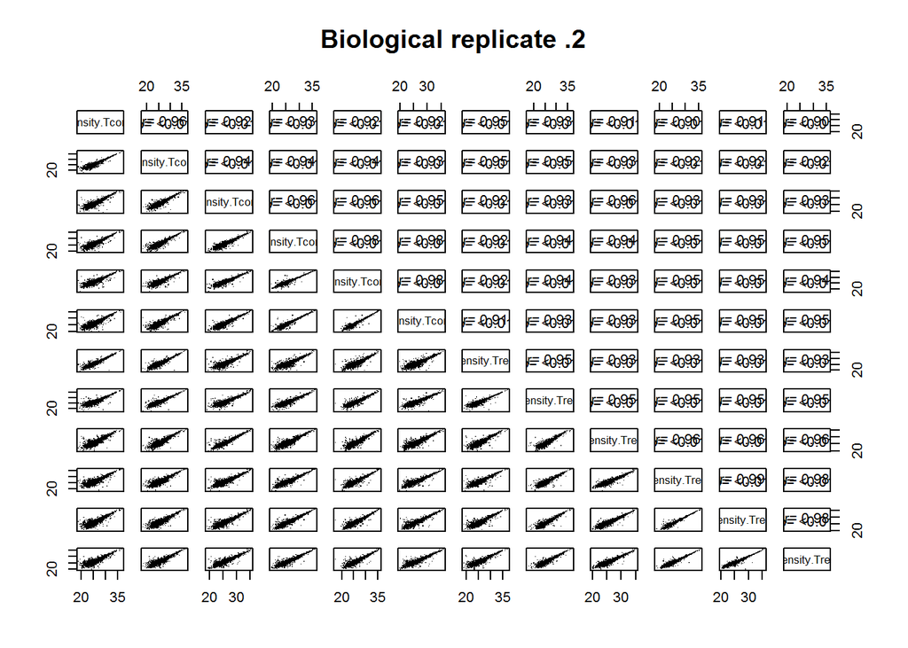

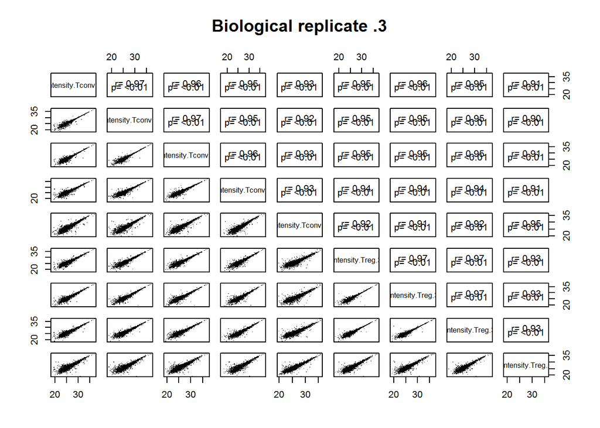

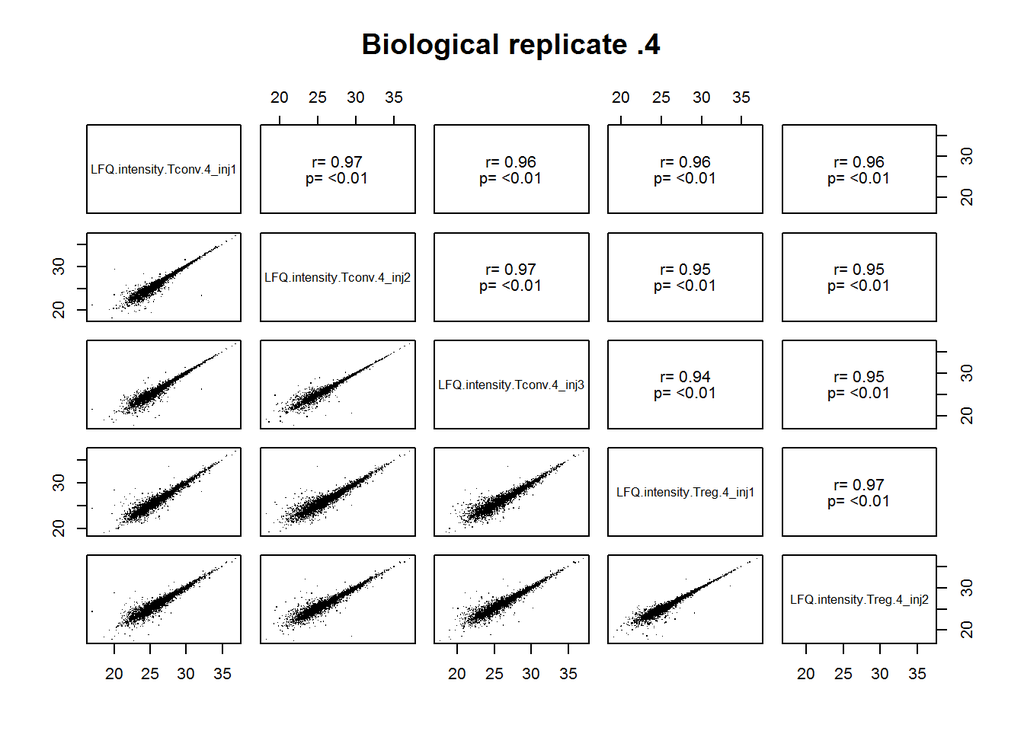

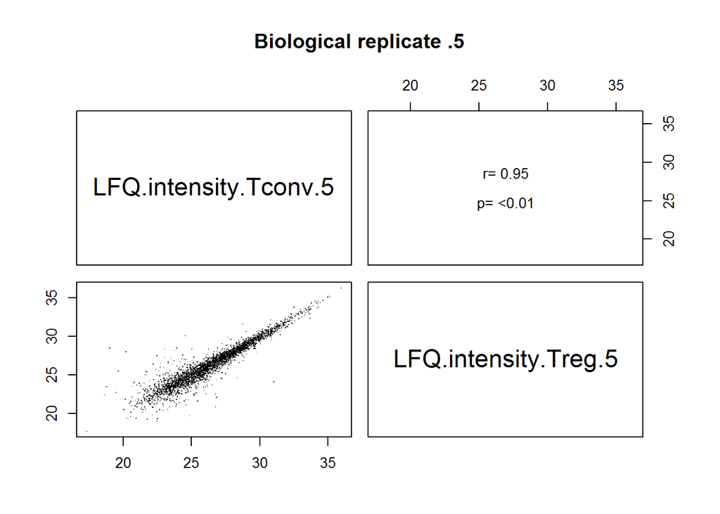

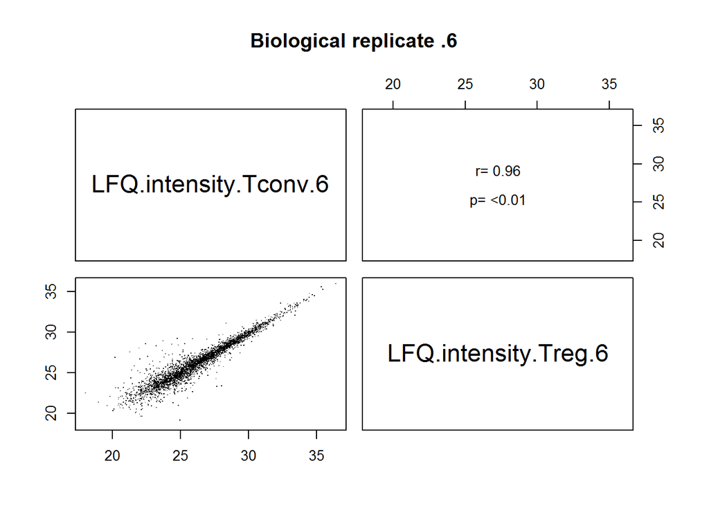

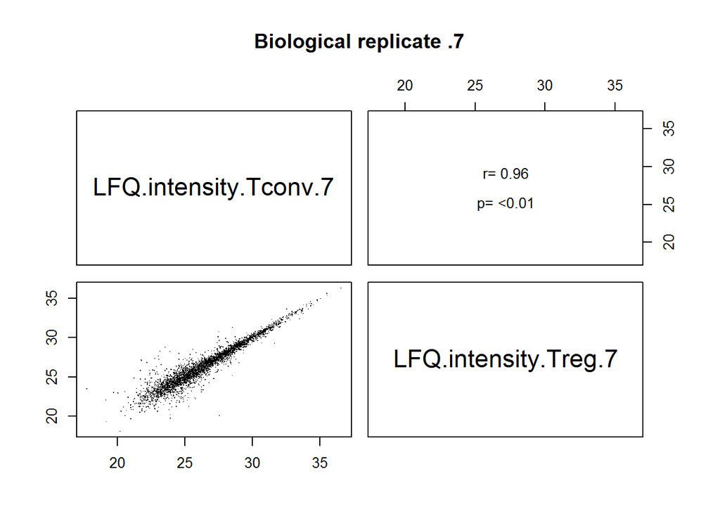

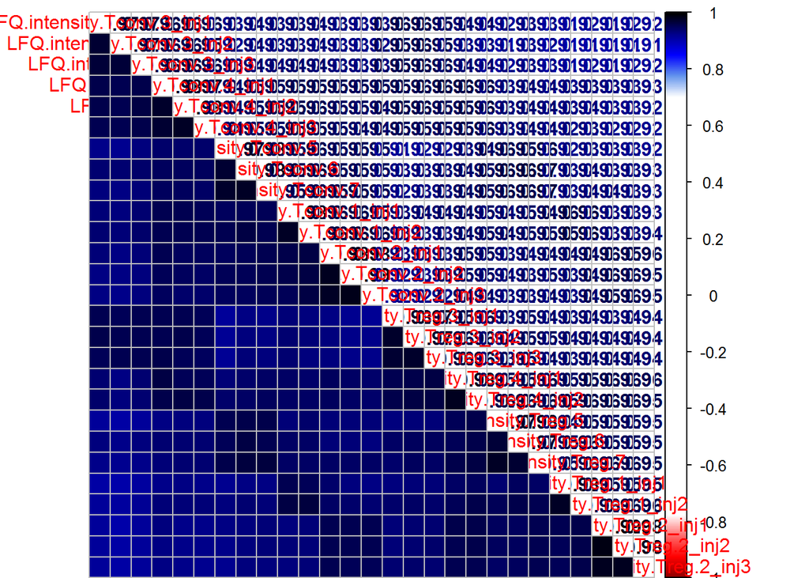

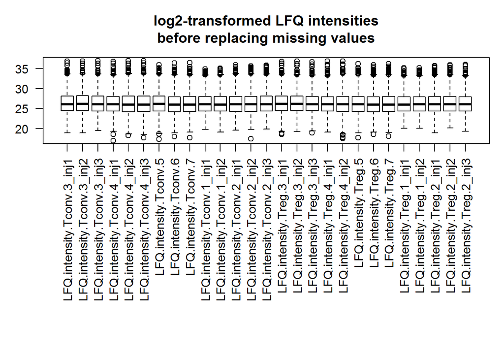

1% quantile per file used to replace missing values:

| file | Replacement.value |
| --- | --- |
| LFQ.intensity.Tconv.3_inj1 | 21.23455 |
| LFQ.intensity.Tconv.3_inj2 | 20.99257 |
| LFQ.intensity.Tconv.3_inj3 | 21.15796 |
| LFQ.intensity.Tconv.4_inj1 | 21.36527 |
| LFQ.intensity.Tconv.4_inj2 | 20.87614 |
| LFQ.intensity.Tconv.4_inj3 | 20.86047 |
| LFQ.intensity.Tconv.5 | 21.15596 |
| LFQ.intensity.Tconv.6 | 20.96491 |
| LFQ.intensity.Tconv.7 | 21.28279 |
| LFQ.intensity.Tconv.1_inj1 | 21.74360 |
| LFQ.intensity.Tconv.1_inj2 | 21.51085 |
| LFQ.intensity.Tconv.2_inj1 | 21.40344 |
| LFQ.intensity.Tconv.2_inj2 | 21.36384 |
| LFQ.intensity.Tconv.2_inj3 | 21.49556 |
| LFQ.intensity.Treg.3_inj1 | 21.16694 |
| LFQ.intensity.Treg.3_inj2 | 21.01175 |
| LFQ.intensity.Treg.3_inj3 | 21.54390 |
| LFQ.intensity.Treg.4_inj1 | 21.43636 |
| LFQ.intensity.Treg.4_inj2 | 21.12007 |
| LFQ.intensity.Treg.5 | 20.82981 |
| LFQ.intensity.Treg.6 | 21.00357 |
| LFQ.intensity.Treg.7 | 21.18910 |
| LFQ.intensity.Treg.1_inj1 | 21.69713 |
| LFQ.intensity.Treg.1_inj2 | 21.66998 |
| LFQ.intensity.Treg.2_inj1 | 21.52701 |
| LFQ.intensity.Treg.2_inj2 | 21.41920 |
| LFQ.intensity.Treg.2_inj3 | 21.46754 |

After having kept only the proteins having a minimum of 3 values from independent biological condition (Tconv or Treg), 3974 proteins remain.

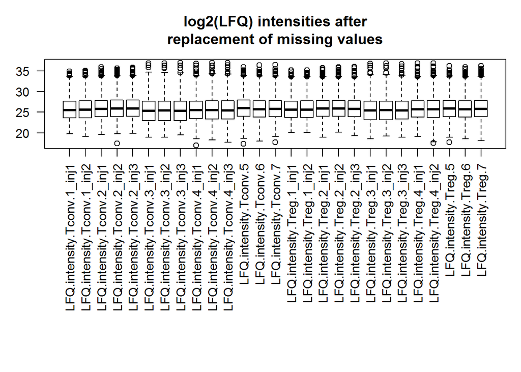

# Mean per biological replicate

The table with the mean values per condition and experiment is saved as `Duguet_Means.txt` in the folder `/OutputTables`. I make the pairwise plots out of curiosity.

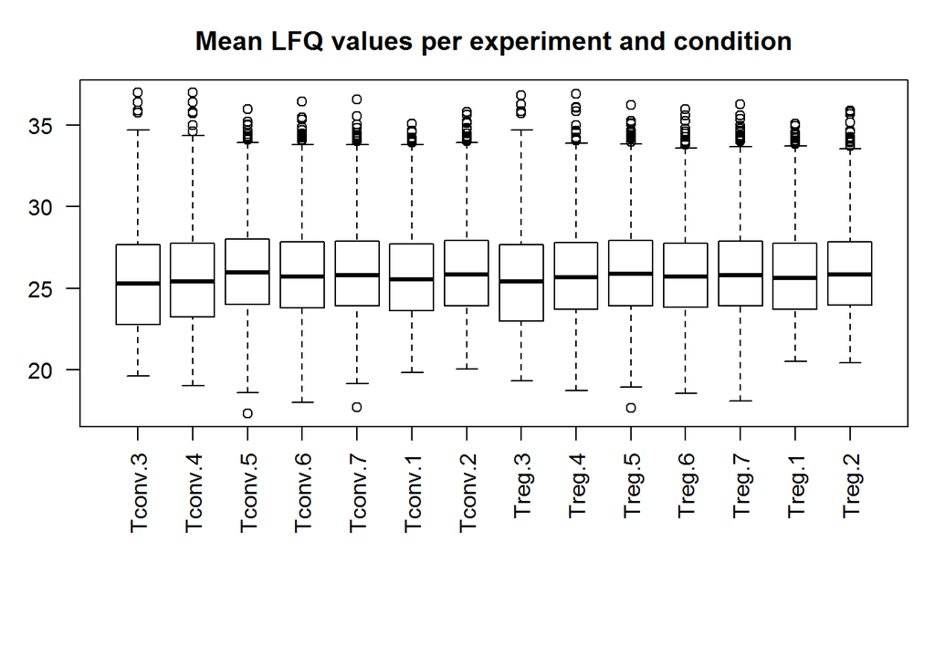

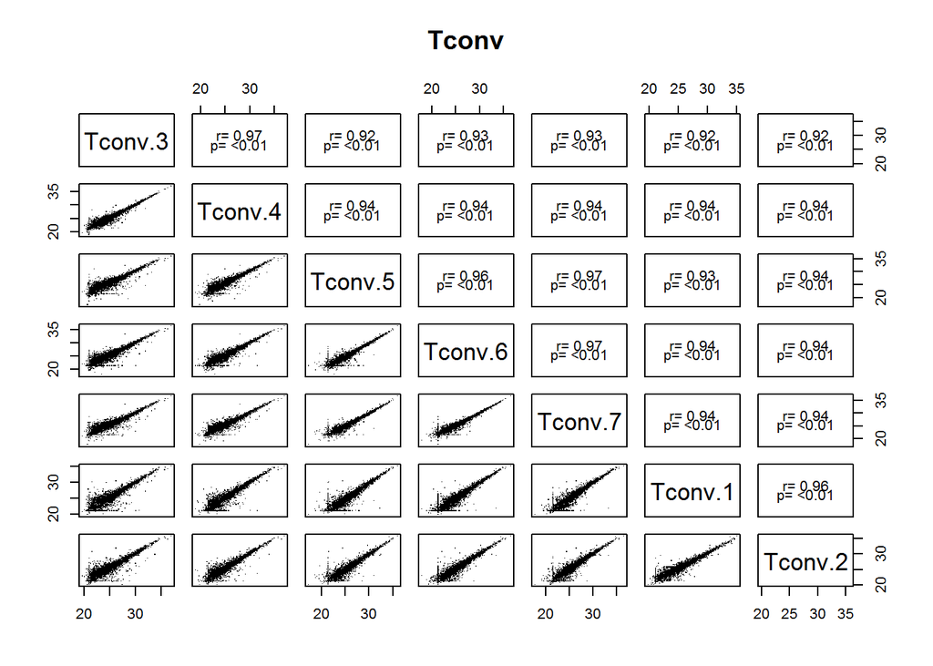

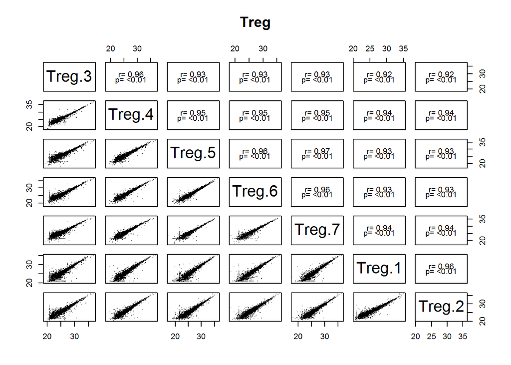

CV values for QC plots:

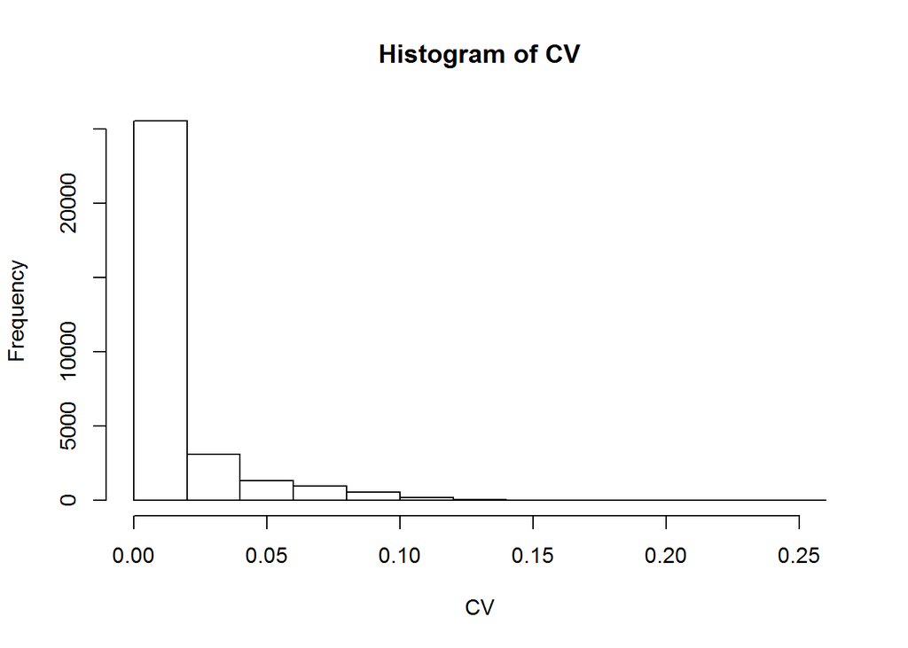

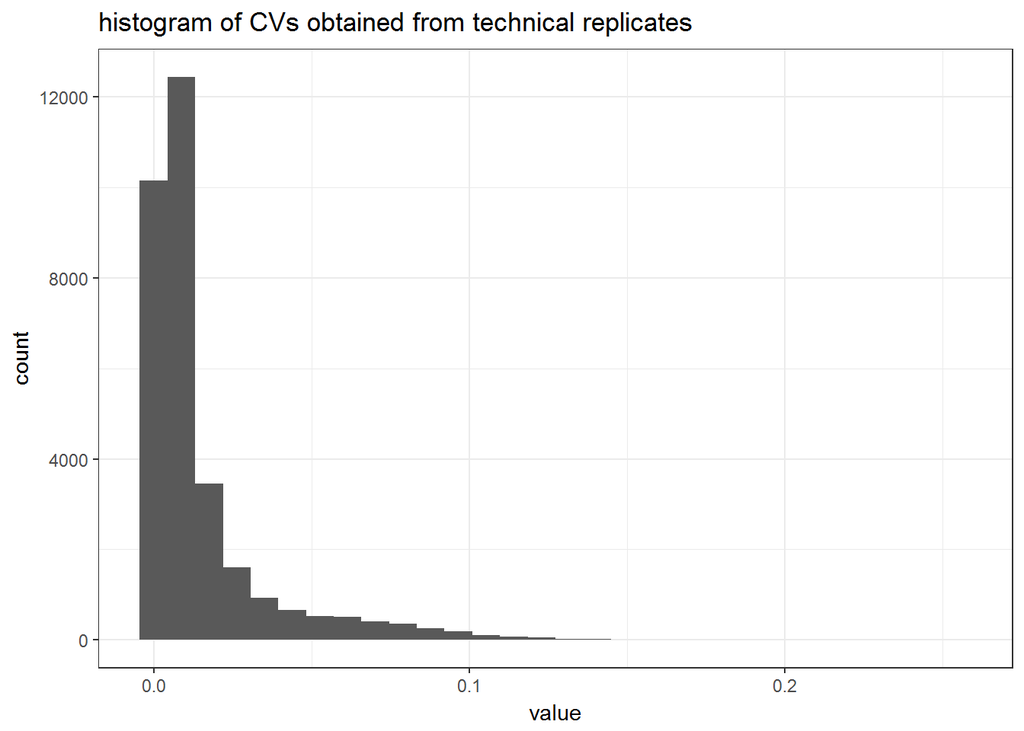

The median of technical CVs is 0.7346871, 99% of the CVs are under 10.0920086 and 90% are under 3.98558.

Correlation between biological replicates and conditions:

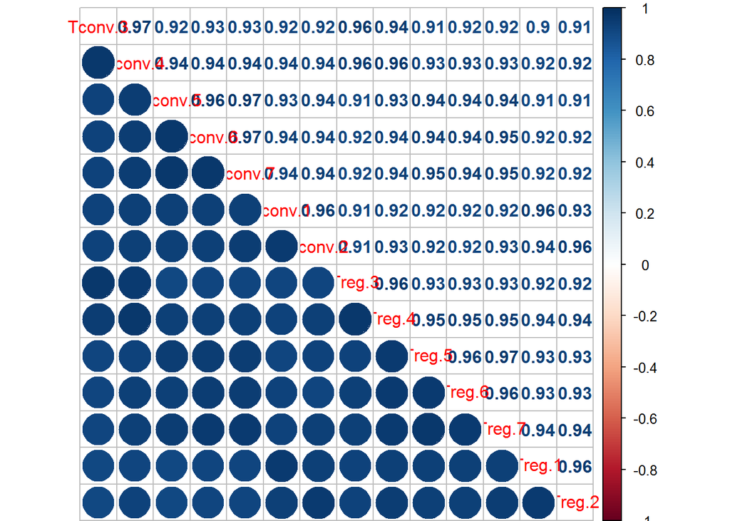

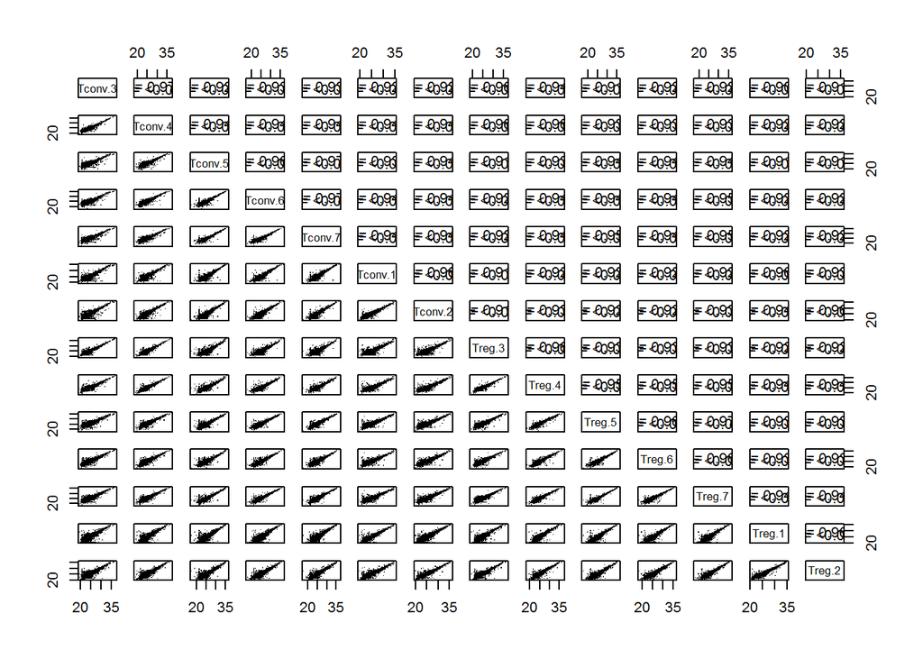

CV between biological replicates and conditions:

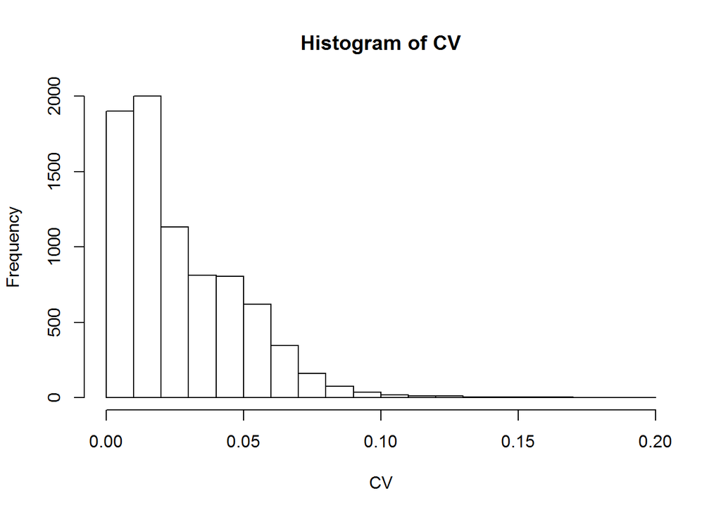

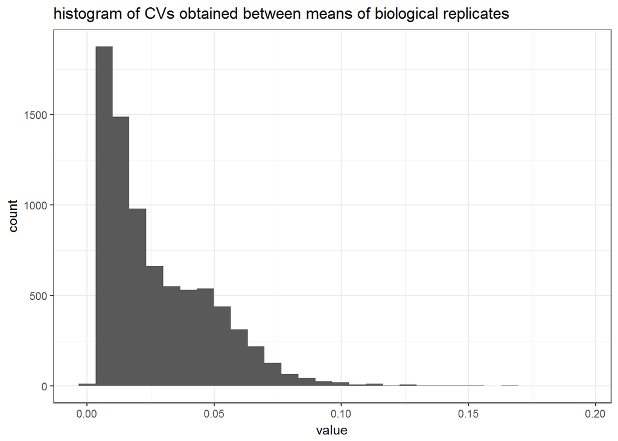

The median of biological CVs is 2.0614777, 99% of the CVs are under 9.4599381 and 90% are under 5.7866916.

# Statistical analysis

In the table with mean values, there are 3974 protein quantified.

We then calculate the pvalue of two-sided paired t-test. The p-values from proteins that have a minimum of 2-fold change between Treg and Tconv (log2(mean(Treg))-log2(mean(Tconv)) above or equal to 1 or log2(mean(Treg))-log2(mean(Tconv)) under or equat to -1) are adjusted (BH). The fold change (FC) coresponds to log2(mean(LFQ in Treg) / Mean(LFQ in Tconv)). Everything is saved with the raw table in the table `OutputTables/2PepOrMore/TotalAnalysisTconvTreg.txt`.

## Volcano plot:

For this volcano plot, I use marker names from the file `MappingTables/MappingMarkers.tab` for colours and shapes. The idea is to localise proteins known to be differentially regulated in the Terg Vs Tconv in the bulk of our proteins.

The output figure is saved as a .pdf: `Figures/2PepOrMore/Volcano.pdf`.

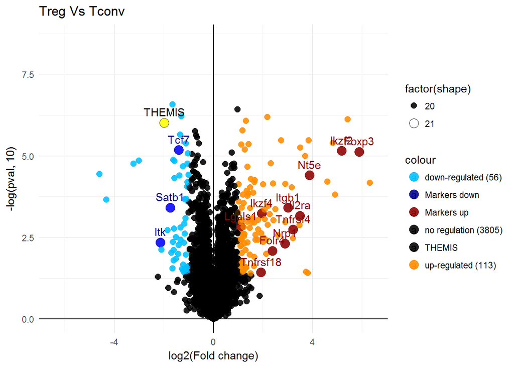

## Bar plot figures with most regulated proteins:

These two plots present the 40 most regulated proteins in the Treg Vs Tconv (up in orange and down in blue). The proteins known to present a different quantity in the two cell populations are highlighted.

The figures are saved as .pdf in the folder `/Figures/2PepOrMore`: `BarPlotUp.pdf` and `BarPlotDown.pdf`.

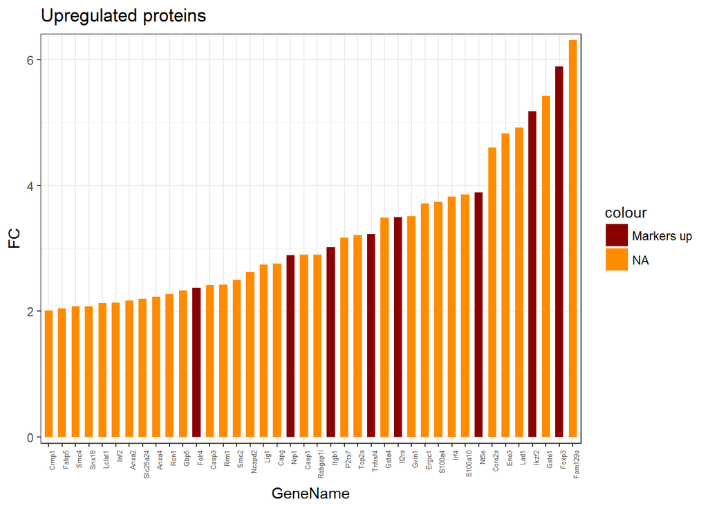

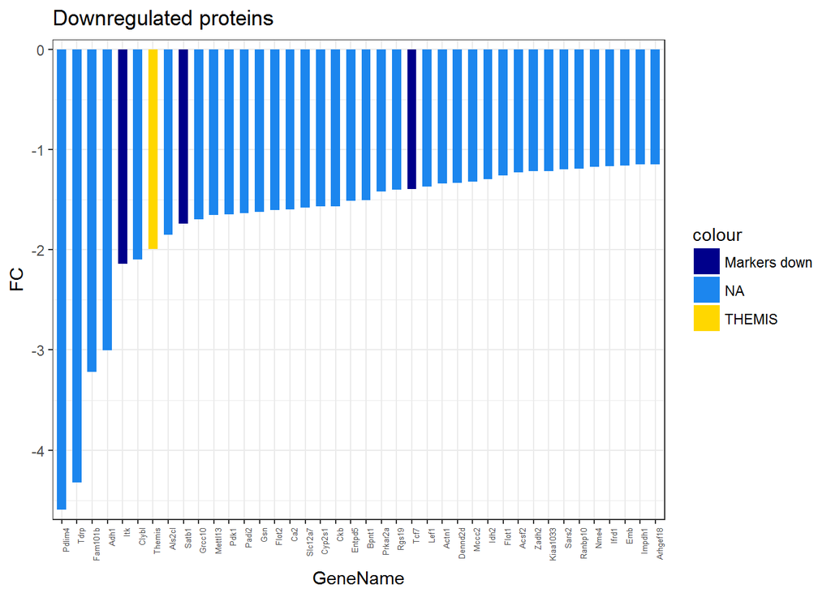

I generate boxplots with the 80 proteins in the barplots (highest fold changes).

I save the individual boxplots in `Figures/2PepOrMore/MultipleBoxplotsUp.pdf` and `Figures/2PepOrMore/MultipleBoxplotsDown.pdf`.

## Heatmap of raw log2(LFQ) values:

This heatmap presents the genes with an absolute log2-transformed fold change above or equal to 1 and a p-value under or equal to 0.05. This heatmap is ordered in function of the sum of the LFQ intensities in the Treg, decreasing. It is named `Figures/2PepOrMore/TileMap.pdf`.

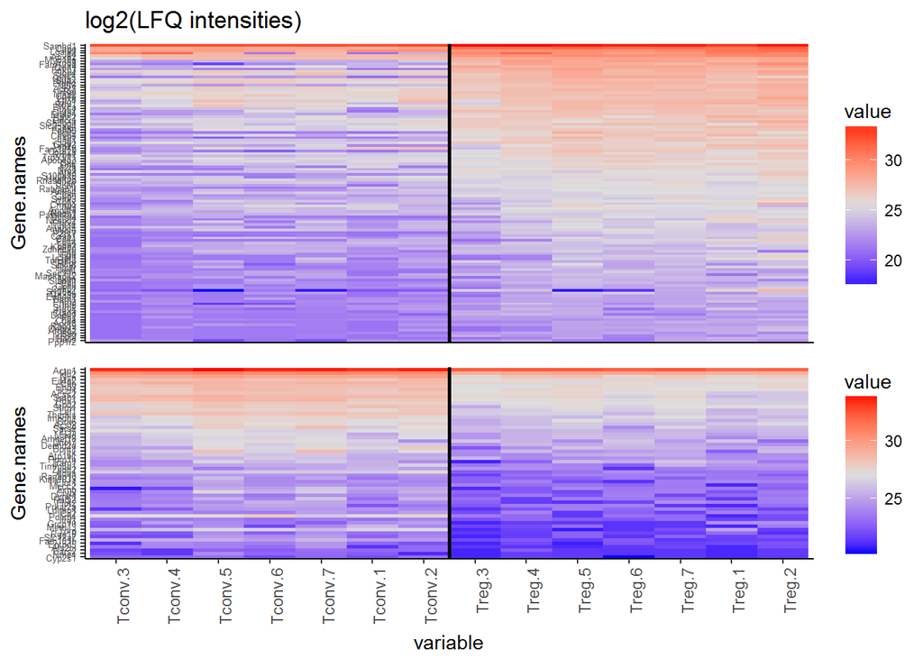

I make the same figure with only the 40 most regulated proteins up and down (corresponds to the proteins in the barcharts). This is called `Figures/2PepOrMore/TileMapRegulated.pdf`.

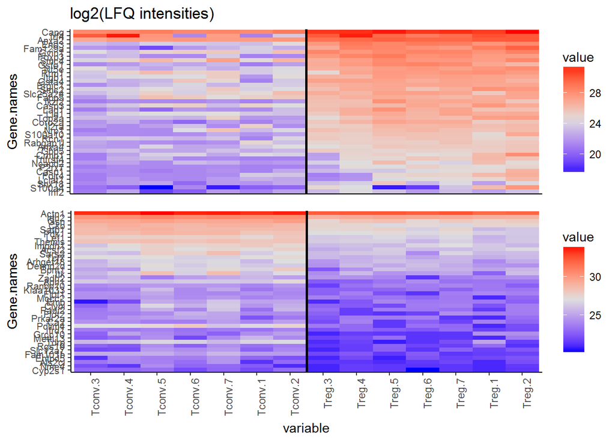

There are 169 proteins with a FC <= -1 or >= 1 (2-fold change between the 2 cell populations) and an adjusted p-value under or equal to 0.05. These are saved in the table `outputTable\SignificativeHits.txt`.

All the figures generated in this document are saved in `Figures\`.